# workers3

```python
#import libraries
import numpy as np
import pandas as pd
import matplotlib.pyplot as plt
import seaborn as sns
import warnings; warnings.simplefilter('ignore')
```

```python
#import the dataset
df=pd.read_csv("desktop/workers_new.csv")
```

```python
df.info()
```

```
<class 'pandas.core.frame.DataFrame'>
RangeIndex: 52016 entries, 0 to 52015
Data columns (total 21 columns):
 #   Column                      Non-Null Count  Dtype
---  ------                      --------------  -----
 0   Unnamed: 0                  52016 non-null  int64
 1   id                          52016 non-null  int64
 2   genderCode                  45737 non-null  object
 3   current_age                 51057 non-null  float64
 4   applicationDate             52016 non-null  object
 5   hiredDate                   52016 non-null  object
 6   app_to_hired_days           52016 non-null  int64
 7   isMobileAppUserFlag         52016 non-null  bool
 8   lightDutyOnlyFlag           52016 non-null  bool
 9   isVeteranFlag               25565 non-null  object
 10  wotcFiledFlag               50886 non-null  object
 11  wotcEligibleFlag            45467 non-null  object
 12  status                      51688 non-null  object
 13  activeFlag                  51688 non-null  object
 14  secondaryStatusDescription  51688 non-null  object
 15  stateName                   50587 non-null  object
 16  workerEducationLevelName    52016 non-null  object
 17  TotalRevenue                21608 non-null  float64
 18  first_revenue_date          21608 non-null  object
 19  last_revenue_date           21608 non-null  object
 20  total_revenue_lines         21608 non-null  float64
dtypes: bool(2), float64(3), int64(3), object(13)
memory usage: 7.6+ MB
```

```python
#change the last_revenue_date from object to datetime
df3 = pd.read_csv("desktop/workers_new.csv", parse_dates=['last_revenue_date'])
```

```python
df3.info()
```

```
<class 'pandas.core.frame.DataFrame'>
RangeIndex: 52016 entries, 0 to 52015
Data columns (total 21 columns):
 #   Column                      Non-Null Count  Dtype
---  ------                      --------------  -----
 0   Unnamed: 0                  52016 non-null  int64
 1   id                          52016 non-null  int64
 2   genderCode                  45737 non-null  object
 3   current_age                 51057 non-null  float64
 4   applicationDate             52016 non-null  object
 5   hiredDate                   52016 non-null  object
 6   app_to_hired_days           52016 non-null  int64
 7   isMobileAppUserFlag         52016 non-null  bool
 8   lightDutyOnlyFlag           52016 non-null  bool
 9   isVeteranFlag               25565 non-null  object
 10  wotcFiledFlag               50886 non-null  object
 11  wotcEligibleFlag            45467 non-null  object
 12  status                      51688 non-null  object
 13  activeFlag                  51688 non-null  object
 14  secondaryStatusDescription  51688 non-null  object
 15  stateName                   50587 non-null  object
 16  workerEducationLevelName    52016 non-null  object
 17  TotalRevenue                21608 non-null  float64
 18  first_revenue_date          21608 non-null  object
 19  last_revenue_date           21608 non-null  datetime64[ns]
 20  total_revenue_lines         21608 non-null  float64
dtypes: bool(2), datetime64[ns](1), float64(3), int64(3), object(12)
memory usage: 7.6+ MB
```

```python
#sort the Total Revenue column from highest to lowest
df2 = df3.sort_values(by=['TotalRevenue'],ascending=False)
```

```python
df2.shape
```

```
(52016, 21)
```

```python
#add column Percetnt to display percentage of Total Revenue
df2['Percent'] = (df['TotalRevenue'] / df['TotalRevenue'].sum()) * 100
```

```python
#add column CumulativePercent
df2['CumulativePercent'] = df2['Percent'].cumsum()
#add column Rank
df2['Rank'] =df2['Percent'].rank(ascending=False)
```

```python
#in hist I put the days between last_revenue_date and today
import datetime as dt
sd = dt.datetime(2022,6,14)
df2['hist']=sd - df2['last_revenue_date']
df2['hist'].astype('timedelta64[D]')
df2['hist']=df2['hist'] / np.timedelta64(1, 'D')
df2.head()
```

|  | Unnamed: 0 | id | genderCode | current_age | applicationDate | hiredDate | app_to_hired_days | isMobileAppUserFlag | lightDutyOnlyFlag | isVeteranFlag | ... | stateName | workerEducationLevelName | TotalRevenue | first_revenue_date | last_revenue_date | total_revenue_lines | Percent | CumulativePercent | Rank | hist |
| --- | --- | --- | --- | --- | --- | --- | --- | --- | --- | --- | --- | --- | --- | --- | --- | --- | --- | --- | --- | --- | --- |
| 49561 | 49561 | 6028898 | M | 78.0 | 2022-01-25 | 2022-02-08 | 14 | False | False | NaN | ... | SOUTH DAKOTA | Not Applicable | 55581.00 | 2022-02-07 | 2022-05-06 | 271.0 | 0.087131 | 0.087131 | 1.0 | 39.0 |
| 11720 | 11720 | 6132652 | M | 38.0 | 2022-04-08 | 2022-04-05 | -3 | True | False | False | ... | NEVADA | Not Applicable | 44984.82 | 2022-04-06 | 2022-05-27 | 40.0 | 0.070520 | 0.157652 | 2.0 | 18.0 |
| 2108 | 2108 | 6002506 | M | 24.0 | 2022-01-08 | 2022-01-11 | 3 | True | False | False | ... | CALIFORNIA | Not Applicable | 44800.46 | 2022-01-10 | 2022-05-07 | 210.0 | 0.070231 | 0.227883 | 3.0 | 38.0 |
| 6253 | 6253 | 5997552 | M | 56.0 | 2022-01-05 | 2022-01-07 | 2 | True | False | False | ... | TEXAS | Not Applicable | 43507.88 | 2022-01-10 | 2022-06-01 | 122.0 | 0.068205 | 0.296088 | 4.0 | 13.0 |
| 28807 | 28807 | 6010278 | M | 41.0 | 2022-01-13 | 2022-01-14 | 1 | True | False | NaN | ... | CALIFORNIA | Not Applicable | 38329.60 | 2022-01-17 | 2022-05-02 | 153.0 | 0.060087 | 0.356175 | 5.0 | 43.0 |

5 rows × 25 columns

```python
#Find the workers that bring 80% of the Revenue and add them to the list_of_TopWorkers
list_of_TopWorkers=[]

for i in df2['CumulativePercent']:
       if(i<80):
            list_of_TopWorkers.append(df2['id'])
```

```python
#Find how many of workers bring 80% of Total Revenue
print(len(list_of_TopWorkers))
```

```
8906
```

```python
#show the number of 20 % of workers with the highest Revenue
print(0.2*52016)
```

```
10403.2
```

```python
#Find the 20 % of workers with the highest Revenue and add their id to the list_of_20_TopWorkers
list_of_20_TopWorkers=[]

for i in range(1,10403):

    list_of_20_TopWorkers.append(df2['id'])
```

```python
#find the total revenue for the 20% of the workers, it shows that 84% of the total revenue is from
#20% of the workers
boolDf = df2['Rank'].isin([10403]).any()
if boolDf:
        print(df2.iloc[10403])
```

```
Unnamed: 0                                  14630
id                                        6007798
genderCode                                      M
current_age                                  27.0
applicationDate                        2022-01-12
hiredDate                              2022-01-18
app_to_hired_days                               6
isMobileAppUserFlag                         False
lightDutyOnlyFlag                           False
isVeteranFlag                               False
wotcFiledFlag                               False
wotcEligibleFlag                              NaN
status                                     Active
activeFlag                                   True
secondaryStatusDescription                 Normal
stateName                                MICHIGAN
workerEducationLevelName           Not Applicable
TotalRevenue                              1553.78
first_revenue_date                     2022-01-17
last_revenue_date             2022-01-21 00:00:00
total_revenue_lines                           6.0
Percent                                  0.002436
CumulativePercent                       84.053497
Rank                                      10404.0
hist                                        144.0
Name: 14630, dtype: object
```

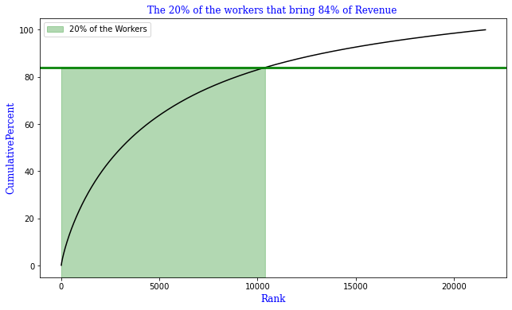

```python
import matplotlib as plt
fig, ax = plt.pyplot.subplots()
fig.set_size_inches(10.5, 6)
N=52016
form1 = {'family': 'serif', 'color': 'Blue', 'size': 12}
x = np.arange(1,N+1,1)
y = df2['CumulativePercent']
ax.plot(x, y, color='black')
plt.pyplot.xlabel("Rank",fontdict=form1)
plt.pyplot.ylabel("CumulativePercent",fontdict=form1)
plt.pyplot.title("The 20% of the workers that bring 84% of Revenue ",fontdict=form1)
threshold = 84
ax.axhline(threshold, color='green', lw=3, alpha=0.9)
ax.fill_between( x,0.81, where=(y < threshold), color='green', alpha=0.3, transform=ax.get_xaxis_transform(),
                label='20% of the Workers')


plt.pyplot.legend()
```

Recency, frequency, monetary value (RFM) is a marketing analysis tool used to identify a firm's best clients based on the nature of their spending habits. Recency: How recently a worker has made a revenue (Last_revenue_date) Frequency: How often a worker makes a revenue (total_revenue_line) Monetary Value: How much money a worker make (TotalRevenue)

```python
#It shows the id is unique in dataset so the frequency doesnt have any meaning for us and I consider recency and monetary value
df2.id.value_counts()
```

```
6028898    1
6189862    1
6188632    1
6189080    1
6189154    1
          ..
6196670    1
6076116    1
5998792    1
6171802    1
6210170    1
Name: id, Length: 52016, dtype: int64
```

```python
#make RFM table
rfmTable = df2.groupby('id').agg({'hist': lambda x:x.min(), # Recency
                                        'TotalRevenue': lambda x: x.sum()})# Monetary Value

rfmTable.rename(columns={'hist': 'recency',
                         'TotalRevenue': 'monetary_value'}, inplace=True)
```

```python
rfmTable = rfmTable.sort_values(by=['monetary_value'],ascending=False)
rfmTable.head()
```

| id | recency | monetary_value |
| --- | --- | --- |
| 6028898 | 39.0 | 55581.00 |
| 6132652 | 18.0 | 44984.82 |
| 6002506 | 38.0 | 44800.46 |
| 5997552 | 13.0 | 43507.88 |
| 6010278 | 43.0 | 38329.60 |

```python
rfmTable = rfmTable[rfmTable["monetary_value"] > 0]
rfmTable.describe().T
```

|  | count | mean | std | min | 25% | 50% | 75% | max |
| --- | --- | --- | --- | --- | --- | --- | --- | --- |
| recency | 21608.0 | 54.510644 | 39.873591 | 12.0 | 19.00 | 41.00 | 83.0000 | 163.0 |
| monetary_value | 21608.0 | 2952.144062 | 3733.780666 | 500.0 | 823.05 | 1476.59 | 3404.6025 | 55581.0 |

```python
#standardize the recency and monetary_value

#Date from customer's last purchase.The nearest date gets 5 and the furthest date gets 1.
rfmTable["recency_score"] = pd.qcut(rfmTable['recency'], 5, labels=[5, 4, 3, 2, 1])

#Total spend by the customer.The least money gets 1, the most money gets 5.
rfmTable["monetary_score"]= pd.qcut(rfmTable["monetary_value"], 5, labels=[1,2,3,4,5])

rfmTable.head()
```

| id | recency | monetary_value | recency_score | monetary_score |
| --- | --- | --- | --- | --- |
| 6028898 | 39.0 | 55581.00 | 3 | 5 |
| 6132652 | 18.0 | 44984.82 | 5 | 5 |
| 6002506 | 38.0 | 44800.46 | 3 | 5 |
| 5997552 | 13.0 | 43507.88 | 5 | 5 |
| 6010278 | 43.0 | 38329.60 | 3 | 5 |

```python
#add RFM_SCORE column
rfmTable["RFM_SCORE"] = (rfmTable["recency_score"].astype(str) + rfmTable["monetary_score"].astype(str))
```

```python
rfmTable.head(2)
```

| id | recency | monetary_value | recency_score | monetary_score | RFM_SCORE |
| --- | --- | --- | --- | --- | --- |
| 6028898 | 39.0 | 55581.00 | 3 | 5 | 35 |
| 6132652 | 18.0 | 44984.82 | 5 | 5 | 55 |

```python
#categorize our workers based on recency and monetary value

seg_map = {
    r'[1-2][1-2]': 'hibernating',
    r'[1-2][3-4]': 'at_Risk',
    r'[1-2]5': 'cant_loose',
    r'3[1-2]': 'about_to_sleep',
    r'33': 'need_attention',
    r'[3-4][4-5]': 'loyal_workers',
    r'41': 'promising',
    r'51': 'new_workers',
    r'[4-5][2-3]': 'potential_loyalists',
    r'5[4-5]': 'champions'
}
rfmTable['segment'] = rfmTable['RFM_SCORE'].replace(seg_map, regex=True)
rfmTable.head(12)
```

| id | recency | monetary_value | recency_score | monetary_score | RFM_SCORE | segment |
| --- | --- | --- | --- | --- | --- | --- |
| 6028898 | 39.0 | 55581.00 | 3 | 5 | 35 | loyal_workers |
| 6132652 | 18.0 | 44984.82 | 5 | 5 | 55 | champions |
| 6002506 | 38.0 | 44800.46 | 3 | 5 | 35 | loyal_workers |
| 5997552 | 13.0 | 43507.88 | 5 | 5 | 55 | champions |
| 6010278 | 43.0 | 38329.60 | 3 | 5 | 35 | loyal_workers |
| 6024118 | 18.0 | 38185.20 | 5 | 5 | 55 | champions |
| 6068354 | 18.0 | 37845.00 | 5 | 5 | 55 | champions |
| 6076636 | 18.0 | 35189.28 | 5 | 5 | 55 | champions |
| 6039114 | 14.0 | 34908.29 | 5 | 5 | 55 | champions |
| 5994610 | 26.0 | 34500.73 | 4 | 5 | 45 | loyal_workers |
| 6007686 | 27.0 | 34138.35 | 4 | 5 | 45 | loyal_workers |
| 6086280 | 18.0 | 33889.14 | 5 | 5 | 55 | champions |

```python
rfmTable.segment.value_counts()
```

```
hibernating            4514
champions              3416
at_Risk                3339
loyal_workers          3012
potential_loyalists    2796
about_to_sleep         1903
need_attention          922
cant_loose              736
promising               581
new_workers             389
Name: segment, dtype: int64
```

[figure not shown]

```python
from matplotlib import pyplot as plt
ri1 = rfmTable.groupby('segment').size()
ri1_labels = ['about_to_sleep', 'at Risk','cant_loose','champions','hibernating','loyal_workers','need_attention','new_workers','potential_loyalists','promising']
fig1 = plt.gcf()
fig1.set_size_inches(7.5,7.5)
plt.pie(ri1, labels=ri1_labels, autopct='%0.001f%%')
plt.gca().axis("equal")
plt.title('different segments of 20% of workers')
plt.legend(ri1, labels=ri1_labels,loc="best") # The Legend
fig1=plt.show()
```

## RFM for 20% of most valuable workers

```python
df3=df2.iloc[:10403]
```

```python
#df3['TotalRevenue'] = df3['TotalRevenue'].fillna(0)
#df3['hist'] = df3['hist'].fillna(0)
```

```python
rfmTable1 = df3.groupby('id').agg({'hist': lambda x:x.min(), # Recency
                                        'TotalRevenue': lambda x: x.sum()}) # Monetary Value

rfmTable1.rename(columns={'hist': 'recency',
                         'TotalRevenue': 'monetary_value'}, inplace=True)
```

```python
rfmTable1.describe().T
```

|  | count | mean | std | min | 25% | 50% | 75% | max |
| --- | --- | --- | --- | --- | --- | --- | --- | --- |
| recency | 10403.0 | 42.522445 | 34.006912 | 12.00 | 17.00 | 26.00 | 62.000 | 157.0 |
| monetary_value | 10403.0 | 5153.908705 | 4418.727776 | 1553.88 | 2246.29 | 3526.09 | 6330.445 | 55581.0 |

```python
rfmTable1 = rfmTable1.sort_values(by=['monetary_value'],ascending=False)
rfmTable1.head()
```

| id | recency | monetary_value |
| --- | --- | --- |
| 6028898 | 39.0 | 55581.00 |
| 6132652 | 18.0 | 44984.82 |
| 6002506 | 38.0 | 44800.46 |
| 5997552 | 13.0 | 43507.88 |
| 6010278 | 43.0 | 38329.60 |

```python
rfmTable1 = rfmTable1[rfmTable1["monetary_value"] > 0]
```

```python
#standardize the recency and monetary_value

#Date from customer's last purchase.The nearest date gets 5 and the furthest date gets 1.
rfmTable1["recency_score"] = pd.qcut(rfmTable1['recency'], 5, labels=[5, 4, 3, 2, 1])

#Total spend by the customer.The least money gets 1, the most money gets 5.
rfmTable1["monetary_score"]= pd.qcut(rfmTable1["monetary_value"], 5, labels=[1,2,3,4,5])

rfmTable1.head()
```

| id | recency | monetary_value | recency_score | monetary_score |
| --- | --- | --- | --- | --- |
| 6028898 | 39.0 | 55581.00 | 3 | 5 |
| 6132652 | 18.0 | 44984.82 | 4 | 5 |
| 6002506 | 38.0 | 44800.46 | 3 | 5 |
| 5997552 | 13.0 | 43507.88 | 5 | 5 |
| 6010278 | 43.0 | 38329.60 | 2 | 5 |

```python
rfmTable1["RFM_SCORE"] = (rfmTable1["recency_score"].astype(str) + rfmTable1["monetary_score"].astype(str))
```

```python
rfmTable1.head(2)
```

| id | recency | monetary_value | recency_score | monetary_score | RFM_SCORE |
| --- | --- | --- | --- | --- | --- |
| 6028898 | 39.0 | 55581.00 | 3 | 5 | 35 |
| 6132652 | 18.0 | 44984.82 | 4 | 5 | 45 |

```python
#categorize our workers based on recency and monetary value

seg_map1 = {
    r'[1-2][1-2]': 'hibernating',
    r'[1-2][3-4]': 'at_Risk',
    r'[1-2]5': 'cant_loose',
    r'3[1-2]': 'about_to_sleep',
    r'33': 'need_attention',
    r'[3-4][4-5]': 'loyal_workers',
    r'41': 'promising',
    r'51': 'new_workers',
    r'[4-5][2-3]': 'potential_loyalists',
    r'5[4-5]': 'champions'
}
rfmTable1['segment'] = rfmTable1['RFM_SCORE'].replace(seg_map1, regex=True)
rfmTable1.head(12)
```

| id | recency | monetary_value | recency_score | monetary_score | RFM_SCORE | segment |
| --- | --- | --- | --- | --- | --- | --- |
| 6028898 | 39.0 | 55581.00 | 3 | 5 | 35 | loyal_workers |
| 6132652 | 18.0 | 44984.82 | 4 | 5 | 45 | loyal_workers |
| 6002506 | 38.0 | 44800.46 | 3 | 5 | 35 | loyal_workers |
| 5997552 | 13.0 | 43507.88 | 5 | 5 | 55 | champions |
| 6010278 | 43.0 | 38329.60 | 2 | 5 | 25 | cant_loose |
| 6024118 | 18.0 | 38185.20 | 4 | 5 | 45 | loyal_workers |
| 6068354 | 18.0 | 37845.00 | 4 | 5 | 45 | loyal_workers |
| 6076636 | 18.0 | 35189.28 | 4 | 5 | 45 | loyal_workers |
| 6039114 | 14.0 | 34908.29 | 5 | 5 | 55 | champions |
| 5994610 | 26.0 | 34500.73 | 3 | 5 | 35 | loyal_workers |
| 6007686 | 27.0 | 34138.35 | 3 | 5 | 35 | loyal_workers |
| 6086280 | 18.0 | 33889.14 | 4 | 5 | 45 | loyal_workers |

```python
rfmTable1.segment.value_counts()
```

```
hibernating            2072
loyal_workers          1887
at_Risk                1591
potential_loyalists    1415
champions              1192
about_to_sleep          946
need_attention          406
cant_loose              377
new_workers             274
promising               243
Name: segment, dtype: int64
```

[figure not shown]

```python
from matplotlib import pyplot as plt
ri1 = rfmTable1.groupby('segment').size()
ri1_labels = ['about_to_sleep', 'at Risk','need_attention','champions','hibernating','loyal_workers','cant_loose','new_workers','potential_loyalists','promising']
fig1 = plt.gcf()
fig1.set_size_inches(7.5,7.5)
plt.pie(ri1, labels=ri1_labels, autopct='%0.001f%%')
plt.gca().axis("equal")
plt.title('different segments of 20% of workers')
plt.legend(ri1, labels=ri1_labels,loc="best") # The Legend
fig1=plt.show()
```

## RFM for the other 80% of workers

```python
df4=df2.iloc[10403:52016]
```

```python
df4.isnull().sum()
```

```
Unnamed: 0                        0
id                                0
genderCode                     5138
current_age                     958
applicationDate                   0
hiredDate                         0
app_to_hired_days                 0
isMobileAppUserFlag               0
lightDutyOnlyFlag                 0
isVeteranFlag                 22072
wotcFiledFlag                  1101
wotcEligibleFlag               5064
status                          328
activeFlag                      328
secondaryStatusDescription      328
stateName                      1429
workerEducationLevelName          0
TotalRevenue                  30408
first_revenue_date            30408
last_revenue_date             30408
total_revenue_lines           30408
Percent                       30408
CumulativePercent             30408
Rank                          30408
hist                          30408
dtype: int64
```

```python
df4['TotalRevenue'] = df4['TotalRevenue'].fillna(0)
df4['hist'] = df4['hist'].fillna(0)
```

```python
df4.shape
```

```
(41613, 25)
```

```python
rfmTable2 = df4.groupby('id').agg({'hist': lambda x:x.min(), # Recency
                                        'TotalRevenue': lambda x: x.sum()})  # Monetary Value

rfmTable2.rename(columns={'hist': 'recency',
                         'TotalRevenue': 'monetary_value'}, inplace=True)
```

```python
rfmTable2.info()
```

```
<class 'pandas.core.frame.DataFrame'>
Int64Index: 41613 entries, 340524 to 6210564
Data columns (total 2 columns):
 #   Column          Non-Null Count  Dtype
---  ------          --------------  -----
 0   recency         41613 non-null  float64
 1   monetary_value  41613 non-null  float64
dtypes: float64(2)
memory usage: 975.3 KB
```

```python
rfmTable2.describe().T
```

|  | count | mean | std | min | 25% | 50% | 75% | max |
| --- | --- | --- | --- | --- | --- | --- | --- | --- |
| recency | 41613.0 | 17.674885 | 36.262814 | 0.0 | 0.0 | 0.0 | 16.0 | 163.00 |
| monetary_value | 41613.0 | 244.486498 | 427.988002 | 0.0 | 0.0 | 0.0 | 587.0 | 1553.78 |

```python
rfmTable2 = rfmTable2.sort_values(by=['monetary_value'],ascending=False)
rfmTable2.head()
```

| id | recency | monetary_value |
| --- | --- | --- |
| 6007798 | 144.0 | 1553.78 |
| 6011430 | 24.0 | 1553.33 |
| 6068392 | 49.0 | 1552.67 |
| 6115266 | 67.0 | 1552.64 |
| 6093036 | 83.0 | 1552.63 |

```python
rfmTable2 = rfmTable2[rfmTable2["monetary_value"] >=0]
```

```python
rfmTable2.shape
```

```
(41613, 2)
```

```python
#Date from customer's last purchase.The nearest date gets 5 and the furthest date gets 1.
rfmTable2["recency"] = rfmTable2["recency"].rank(method='first')
rfmTable2["recency_score"] = pd.qcut(rfmTable2['recency'], 5, labels=[5, 4, 3, 2, 1])

rfmTable2["monetary_value"] = rfmTable2["monetary_value"].rank(method='first')
#Total spend by the customer.The least money gets 1, the most money gets 5.
rfmTable2["monetary_score"]= pd.qcut(rfmTable2['monetary_value'], 5 ,labels=[1,2,3,4,5])
rfmTable2.head()
```

[output not shown]

```python
rfmTable2["RFM_SCORE"] = (rfmTable2["recency_score"].astype(str) + rfmTable2["monetary_score"].astype(str))
```

```python
rfmTable2['segment'] = rfmTable2['RFM_SCORE'].replace(seg_map, regex=True)
rfmTable2.head(12000)
```

[output not shown]

12000 rows × 8 columns

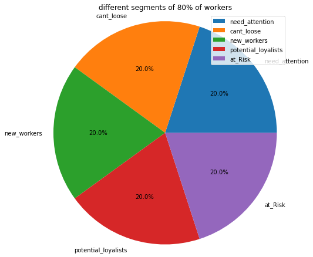

```python
ri1 = rfmTable2.groupby('segment').size()
ri1_labels = ['need_attention','cant_loose','new_workers','potential_loyalists','at_Risk']
fig1 = plt.gcf()
fig1.set_size_inches(7.5,7.5)
plt.pie(ri1, labels=ri1_labels, autopct='%0.001f%%')
plt.gca().axis("equal")
plt.title('different segments of 80% of workers')
plt.legend(ri1, labels=ri1_labels,loc="best") # The Legend
fig1=plt.show()
```

```python
rfmTable2.segment.value_counts()
```

```
cant_loose             8323
new_workers            8323
need_attention         8323
at_Risk                8322
potential_loyalists    8322
Name: segment, dtype: int64
```

```python
rfmTable1.segment.value_counts()
```

```
hibernating            2072
loyal_workers          1887
at_Risk                1591
potential_loyalists    1415
champions              1192
about_to_sleep          946
need_attention          406
cant_loose              377
new_workers             274
promising               243
Name: segment, dtype: int64
```

### the mean of the monetary_value for the 20% of valuable workers= 5154 which is higher than the mean of monetary_value =244 for the rest 80% of workers

```python
df4.info()
```

```
<class 'pandas.core.frame.DataFrame'>
Int64Index: 41613 entries, 14630 to 52015
Data columns (total 25 columns):
 #   Column                      Non-Null Count  Dtype
---  ------                      --------------  -----
 0   Unnamed: 0                  41613 non-null  int64
 1   id                          41613 non-null  int64
 2   genderCode                  36475 non-null  object
 3   current_age                 40655 non-null  float64
 4   applicationDate             41613 non-null  object
 5   hiredDate                   41613 non-null  object
 6   app_to_hired_days           41613 non-null  int64
 7   isMobileAppUserFlag         41613 non-null  bool
 8   lightDutyOnlyFlag           41613 non-null  bool
 9   isVeteranFlag               19541 non-null  object
```

[output cut: 17 more lines]

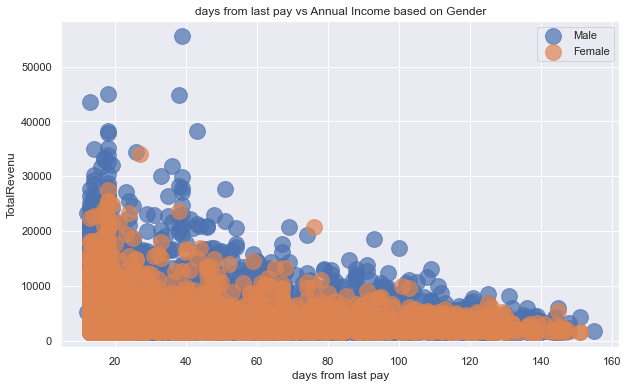

```python
import matplotlib.pyplot as plt
plt.figure(1 , figsize = (10 , 6))
for gender in ['Male' , 'Female']:
    plt.scatter(x = 'hist' , y = 'TotalRevenue' , data = df3[df3['genderCode'] == gender] ,
                s = 250 , alpha = 0.7 , label = gender)
plt.xlabel('days from last pay'), plt.ylabel('TotalRevenu')
plt.title('days from last pay vs Annual Income based on Gender')
plt.legend()
plt.show()
```

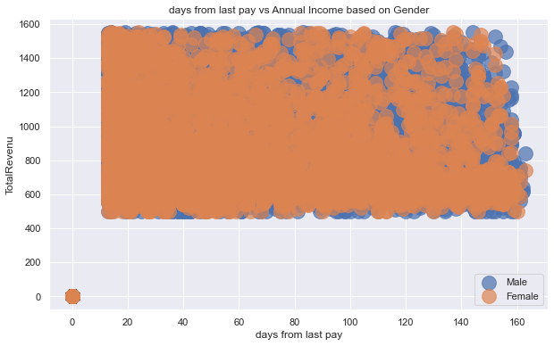

```python
import matplotlib.pyplot as plt
plt.figure(1 , figsize = (10 , 6))
for gender in ['Male' , 'Female']:
    plt.scatter(x = 'hist' , y = 'TotalRevenue' , data = df4[df4['genderCode'] == gender] ,
                s = 250 , alpha = 0.7 , label = gender)
plt.xlabel('days from last pay'), plt.ylabel('TotalRevenu')
plt.title('days from last pay vs Annual Income based on Gender')
plt.legend()
plt.show()
```

## Gender

```python
#change the M to Male and F to Female in genderCode column
df3['genderCode'].replace('M','Male',inplace=True)
df3['genderCode'].replace('F','Female',inplace=True)
```

```python
#show the number of counts for each genderCode
customer_genderCode=df3[['genderCode','id']].drop_duplicates()
customer_genderCode.groupby(['genderCode'])['id'].aggregate('count').reset_index().sort_values('id', ascending=False)
```

|  | genderCode | id |
| --- | --- | --- |
| 1 | Male | 6788 |
| 0 | Female | 2474 |

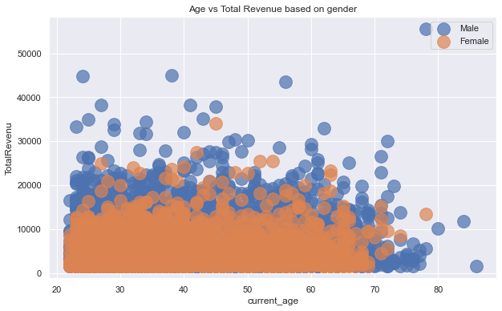

```python
plt.figure(1 , figsize = (10 , 6))
for gender in ['Male' , 'Female']:
    plt.scatter(x = 'current_age' , y = 'TotalRevenue' , data = df3[df3['genderCode'] == gender] ,
                s = 250 , alpha = 0.7 , label = gender)
plt.xlabel('current_age'), plt.ylabel('TotalRevenu')
plt.title('Age vs Total Revenue based on gender')
plt.legend()
plt.show()
```

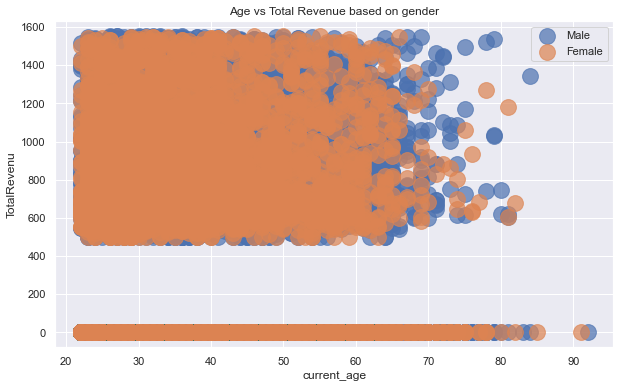

```python
plt.figure(1 , figsize = (10 , 6))
for gender in ['Male' , 'Female']:
    plt.scatter(x = 'current_age' , y = 'TotalRevenue' , data = df4[df4['genderCode'] == gender] ,
                s = 250 , alpha = 0.7 , label = gender)
plt.xlabel('current_age'), plt.ylabel('TotalRevenu')
plt.title('Age vs Total Revenue based on gender')
plt.legend()
plt.show()
```

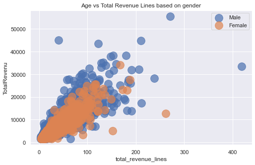

```python
plt.figure(1 , figsize = (8, 5))
for gender in ['Male' , 'Female']:
    plt.scatter(x = 'total_revenue_lines' , y = 'TotalRevenue' , data = df3[df3['genderCode'] == gender] ,
                s = 250 , alpha = 0.7 , label = gender)
plt.xlabel('total_revenue_lines'), plt.ylabel('TotalRevenu')
plt.title('Age vs Total Revenue Lines based on gender')
plt.legend()
plt.show()
```

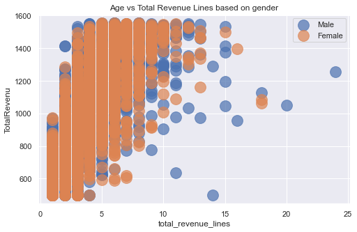

```python
plt.figure(1 , figsize = (8, 5))
for gender in ['Male' , 'Female']:
    plt.scatter(x = 'total_revenue_lines' , y = 'TotalRevenue' , data = df4[df4['genderCode'] == gender] ,
                s = 250 , alpha = 0.7 , label = gender)
plt.xlabel('total_revenue_lines'), plt.ylabel('TotalRevenu')
plt.title('Age vs Total Revenue Lines based on gender')
plt.legend()
plt.show()
```

### Compare the status for 20% of workers and 80% of workers

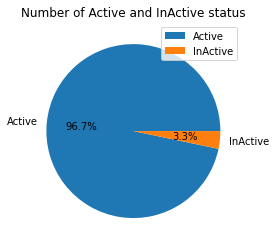

```python
ri1 = df3.groupby('status').size()
ri1_labels = ['Active', 'InActive']
plt.pie(ri1, labels=ri1_labels, autopct='%.1f%%')
plt.title('Number of Active and InActive status')
plt.legend()
plt.show()
```

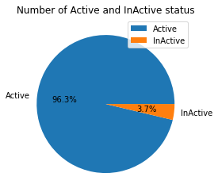

```python
ri2 = df4.groupby('status').size()
ri2_labels = ['Active', 'InActive']
plt.pie(ri2, labels=ri2_labels, autopct='%.1f%%')
plt.title('Number of Active and InActive status')
plt.legend()
plt.show()
```

### Compare the for isMobileAppUserFlag 20% of workers and 80% of workers

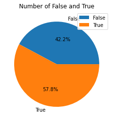

```python
ri1 = df3.groupby('isMobileAppUserFlag').size()
ri1_labels = ['False', 'True']
plt.pie(ri1, labels=ri1_labels, autopct='%.1f%%')
plt.title('Number of False and True')
plt.legend()
plt.show()
```

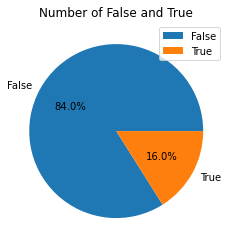

```python
ri1 = df4.groupby('isMobileAppUserFlag').size()
ri1_labels = ['False', 'True']
plt.pie(ri1, labels=ri1_labels, autopct='%.1f%%')
plt.title('Number of False and True')
plt.legend()
plt.show()
```

### The above two pie chart show that 20% of workers which are more usefull use MobileApp more than the other 80 % of workers(about 3.5 times)

```python
#change the M to Male and F to Female in genderCode column
df4['genderCode'].replace('M','Male',inplace=True)
df4['genderCode'].replace('F','Female',inplace=True)
```

```python
#show the number of counts for each genderCode
customer_genderCode=df4[['genderCode','id']].drop_duplicates()
customer_genderCode.groupby(['genderCode'])['id'].aggregate('count').reset_index().sort_values('id', ascending=False)
```

|  | genderCode | id |
| --- | --- | --- |
| 1 | Male | 21714 |
| 0 | Female | 14761 |

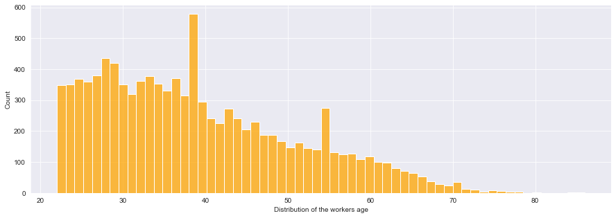

```python
import seaborn as sns
from matplotlib import pyplot as plt
sns.set_style("darkgrid")
f, ax = plt.subplots(figsize=(15,5))
ax = sns.histplot(data=df3, x='current_age', bins=60, color='orange')
ax.set_xlabel('Distribution of the workers age')
plt.show()
```

```python
df4.current_age.mean()
```

```
37.02009592916001
```

```python
df3.current_age.mean()
```

```
39.16352624495289
```

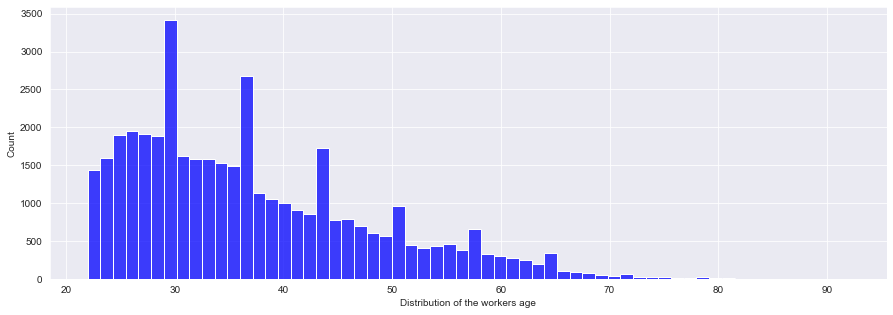

```python
import seaborn as sns
from matplotlib import pyplot as plt
sns.set_style("darkgrid")
f, ax = plt.subplots(figsize=(15,5))
ax = sns.histplot(data=df4, x='current_age', bins=60, color='blue')
ax.set_xlabel('Distribution of the workers age')
plt.show()
```

### The above two graphs show that for the 20% of workers which are more usefull, are a little older than the other 80%

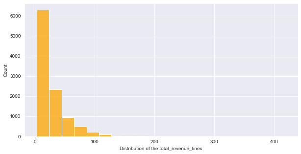

```python
#for 20% of workers
import seaborn as sns
from matplotlib import pyplot as plt
sns.set_style("darkgrid")
f, ax = plt.subplots(figsize=(10,5))
ax = sns.histplot(data=df3, x='total_revenue_lines', bins=20, color='orange')
ax.set_xlabel('Distribution of the total_revenue_lines')
plt.show()
```

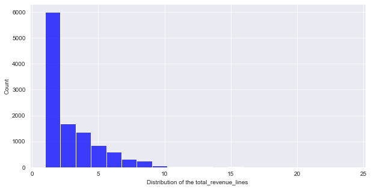

```python
#for 80% of workers
import seaborn as sns
from matplotlib import pyplot as plt
sns.set_style("darkgrid")
f, ax = plt.subplots(figsize=(10,5))
ax = sns.histplot(data=df4, x='total_revenue_lines', bins=20, color='blue')
ax.set_xlabel('Distribution of the total_revenue_lines')
plt.show()
```

```python
df3.total_revenue_lines.max()
```

```
419.0
```

```python
df3.total_revenue_lines.sum()
```

```
281445.0
```

```python
df4.total_revenue_lines.max()
```

```
24.0
```

```python
df4.total_revenue_lines.sum()
```

```
32656.0
```

### The above two graphs show that for the 20% of workers with more total revenue have more total_revenue_lines

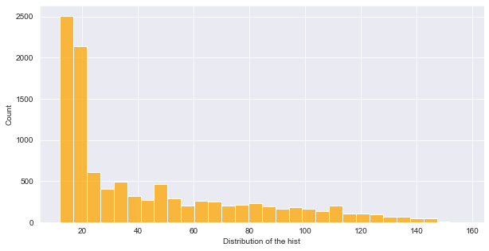

```python
#for 20% of workers
import seaborn as sns
from matplotlib import pyplot as plt
sns.set_style("darkgrid")
f, ax = plt.subplots(figsize=(10,5))
ax = sns.histplot(data=df3, x='hist', bins=30, color='orange')
ax.set_xlabel('Distribution of the hist')
plt.show()
```

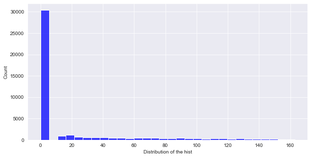

```python
#for 80% of workers
import seaborn as sns
from matplotlib import pyplot as plt
sns.set_style("darkgrid")
f, ax = plt.subplots(figsize=(10,5))
ax = sns.histplot(data=df4, x='hist', bins=30, color='blue')
ax.set_xlabel('Distribution of the hist')
plt.show()
```

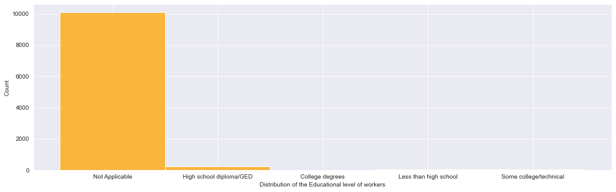

```python
#for 20% of workers
import seaborn as sns
from matplotlib import pyplot as plt
sns.set_style("darkgrid")
f, ax = plt.subplots(figsize=(17,5))
ax = sns.histplot(data=df3, x='workerEducationLevelName', bins=10, color='orange')
ax.set_xlabel('Distribution of the Educational level of workers')
plt.show()
```

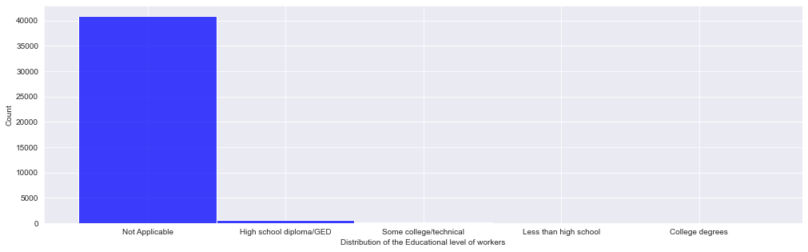

```python
#for 80% of workers
import seaborn as sns
from matplotlib import pyplot as plt
sns.set_style("darkgrid")
f, ax = plt.subplots(figsize=(17,5))
ax = sns.histplot(data=df4, x='workerEducationLevelName', bins=10, color='blue')
ax.set_xlabel('Distribution of the Educational level of workers')
plt.show()
```

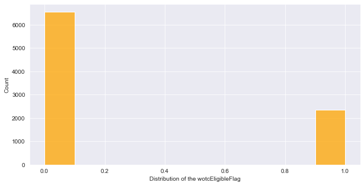

```python
#for 20% of workers
import seaborn as sns
from matplotlib import pyplot as plt
sns.set_style("darkgrid")
f, ax = plt.subplots(figsize=(10,5))
ax = sns.histplot(data=df3, x='wotcEligibleFlag', bins=10, color='orange')
ax.set_xlabel('Distribution of the wotcEligibleFlag')
plt.show()
```

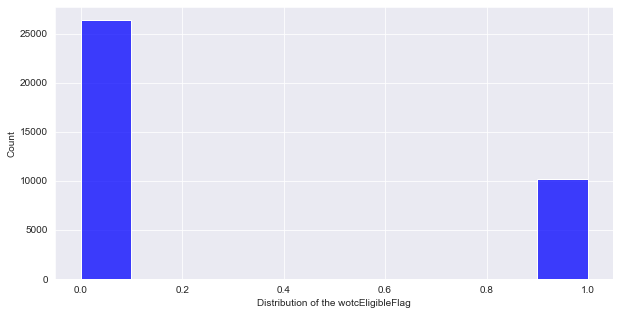

```python
#for 80% of workers
import seaborn as sns
from matplotlib import pyplot as plt
sns.set_style("darkgrid")
f, ax = plt.subplots(figsize=(10,5))
ax = sns.histplot(data=df4, x='wotcEligibleFlag', bins=10, color='blue')
ax.set_xlabel('Distribution of the wotcEligibleFlag')
plt.show()
```

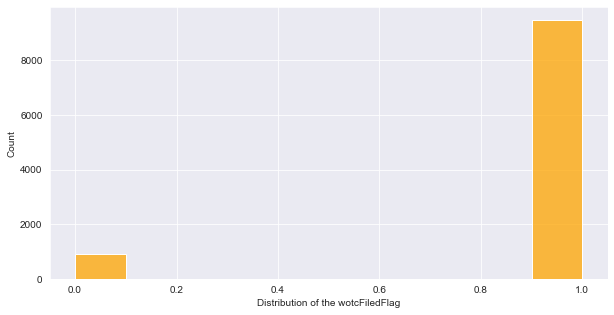

```python
#for 20% of workers
import seaborn as sns
from matplotlib import pyplot as plt
sns.set_style("darkgrid")
f, ax = plt.subplots(figsize=(10,5))
ax = sns.histplot(data=df3, x='wotcFiledFlag', bins=10, color='orange')
ax.set_xlabel('Distribution of the wotcFiledFlag')
plt.show()
```

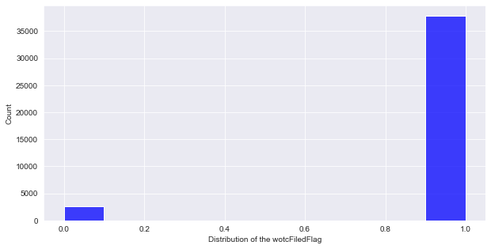

```python
#for 80% of workers
import seaborn as sns
from matplotlib import pyplot as plt
sns.set_style("darkgrid")
f, ax = plt.subplots(figsize=(10,5))
ax = sns.histplot(data=df4, x='wotcFiledFlag', bins=10, color='blue')
ax.set_xlabel('Distribution of the wotcFiledFlag')
plt.show()
```

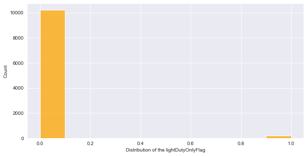

```python
#for 20% of workers
import seaborn as sns
from matplotlib import pyplot as plt
sns.set_style("darkgrid")
f, ax = plt.subplots(figsize=(10,5))
ax = sns.histplot(data=df3, x='lightDutyOnlyFlag', bins=10, color='orange')
ax.set_xlabel('Distribution of the lightDutyOnlyFlag')
plt.show()
```

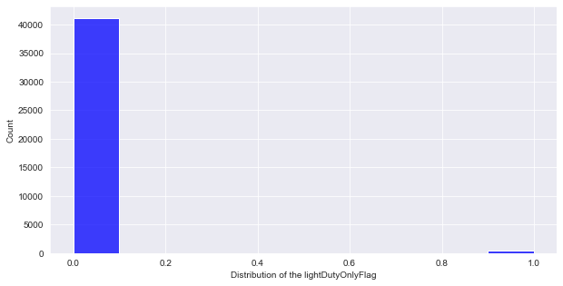

```python
#for 80% of workers
import seaborn as sns
from matplotlib import pyplot as plt
sns.set_style("darkgrid")
f, ax = plt.subplots(figsize=(10,5))
ax = sns.histplot(data=df4, x='lightDutyOnlyFlag', bins=10, color='blue')
ax.set_xlabel('Distribution of the lightDutyOnlyFlag')
plt.show()
```

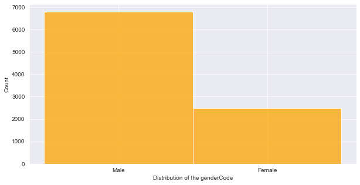

```python
#for 20% of workers
import seaborn as sns
from matplotlib import pyplot as plt
sns.set_style("darkgrid")
f, ax = plt.subplots(figsize=(10,5))
ax = sns.histplot(data=df3, x='genderCode', bins=10, color='orange')
ax.set_xlabel('Distribution of the genderCode')
plt.show()
```

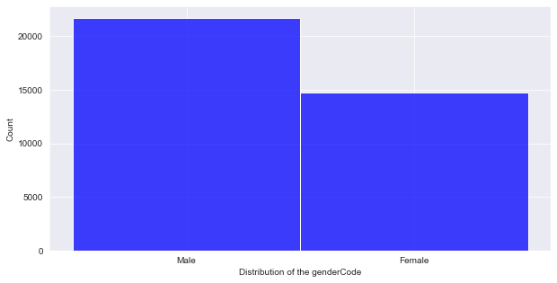

```python
#for 80% of workers
import seaborn as sns
from matplotlib import pyplot as plt
sns.set_style("darkgrid")
f, ax = plt.subplots(figsize=(10,5))
ax = sns.histplot(data=df4, x='genderCode', bins=10, color='blue')
ax.set_xlabel('Distribution of the genderCode')
plt.show()
```